# GSK x Digdata R Challenge

Author

GSK

Published

1 May 2023

Welcome!

Your job is to analyse the data from the clinical trial (or “study”) which was conducted to determine whether Miraculon-A is superior to the current standard of care for patients who have a certain type of solid tumours. You’ll do this using the *R programming language*.

First thing’s first, you’ll need to set up your development environment. Create an account on [Posit Cloud](https://posit.cloud) if you haven’t already done so. You’re also free to instead download and install [RStudio](https://posit.co/products/open-source/rstudio/) and work on your local machine if you’d prefer, but the instructions here assume Posit Cloud (which is essentially RStudio online).

Once you’re in you should see *Your Workspace*, if not navigate there via the sidebar. Now create a new RStudio project:

[figure not shown]

Your view should now look like this:

[figure not shown]

Go ahead and rename the project by clicking at the top. It’s also worth a quick play with the *console* to confirm everything’s in order:

[figure not shown]

Next, direct your attention to the bottom right pane and select *upload*. You need to upload both of the provided CSV files:

[figure not shown]

Now create a “New Blank File” –> “R Script” to contain the code for this analysis, naming it whatever you like. Open it up and add `library(tidyverse)` to the first line. This will load the well-known set of R packages from *Tidyverse*, such as *dplyr* and *ggplot2*. You should automatically be prompted to install tidyverse:

[figure not shown]

If not, run this command in the console: `install.packages("tidyverse")`

Finally, add two lines of code like in the following screenshot and then hit the “Source” button to execute the entirety of the script:

[figure not shown]

It’s worth clicking the little dropdown for the Source button and changing the default to “Source with Echo”. This will ensure the output of various functions will appear in the console when you press the button to run your whole script.

The interface for RStudio is quite busy so you may wish to refer to the [cheat sheet](https://posit.co/wp-content/uploads/2022/10/rstudio-ide-1.pdf) if you’re unsure about something. For a gentle video introduction check out [this video](https://www.youtube.com/watch?v=FIrsOBy5k58).

You’re now ready to begin coding!

**Tip**

If you get stuck, don’t be afraid to search online! There are a plethora of online resources available, such as [*StackOverflow*](https://stackoverflow.com/questions/tagged/r?sort=MostVotes), which is the most popular place for support amongst the programming community.

If you’re very new to R, or even programming, have no fear! Make your way through these exercises as best you can. The book [*R for Data Science*](https://r4ds.had.co.nz/) is arguably the best place to begin, we’ll refer to it frequently, and it’s available online for free! More resources are linked at the end of this doc.

## 1 Read in the data

The first thing you need to do is read in the provided data into an R dataframe[^1]. The file containing the data is `clinical-study.csv`.

Use the `read_csv()` function. You should only need to provide it with one argument: a string representing the filename/path of the .csv file you want to read in.

Recall that R can store values, including the output of functions, in *objects*. For example, `my_result <- sqrt(4)` stores the output of calling the square root function on 4 in an object called my_result.

[Chapter 4 of *R for Data Science*](https://r4ds.had.co.nz/workflow-basics.html) has a concise explanation of this.

Be sure to store the dataframe in an object with a suitable name in snake_case, such as `study_df`.

If you’ve successfully read the data from the file into an object, you should see something like this in the *Environment* window in the top right:

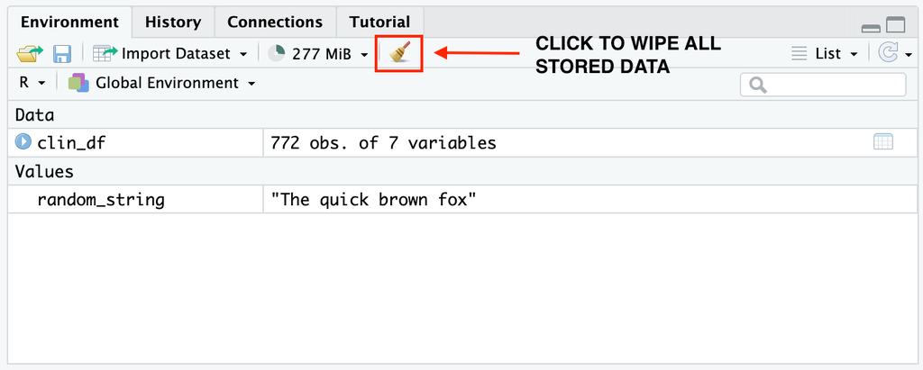

You’ll occasionally want to wipe all data currently stored in the environment. For example, if you want to re-run (i.e. source) your whole script, to ensure no conflict with some data already being present.

## 2 Examine the data

It’s always worth examining your data before making any changes. The function `head()` is a convenient way to peek at the first n rows of a dataframe. Take a look at this example with the `starwars` dataset which is bundled in Tidyverse:

```r
library(tidyverse)

head(starwars, 7)
```

```
# A tibble: 7 × 14
  name      height  mass hair_color skin_color eye_color birth_year sex   gender
  <chr>      <int> <dbl> <chr>      <chr>      <chr>          <dbl> <chr> <chr>
1 Luke Sky…    172    77 blond      fair       blue            19   male  mascu…
2 C-3PO        167    75 <NA>       gold       yellow         112   none  mascu…
3 R2-D2         96    32 <NA>       white, bl… red             33   none  mascu…
4 Darth Va…    202   136 none       white      yellow          41.9 male  mascu…
5 Leia Org…    150    49 brown      light      brown           19   fema… femin…
6 Owen Lars    178   120 brown, gr… light      blue            52   male  mascu…
7 Beru Whi…    165    75 brown      light      blue            47   fema… femin…
# ℹ 5 more variables: homeworld <chr>, species <chr>, films <list>,
#   vehicles <list>, starships <list>
```

This is helpful but you can get a fuller, clearer and more interactive view by using the function `view()`. Give it a go!

Finally, try using the `summary()` function on the dataframe. See anything interesting?

## 3 Clean up the data

Cleaning the data is an unglamorous but necessary task. There are several ways it should be cleaned up. Let’s go through them one by one.

### 3.1 Rename columns

This is a straightforward but important one. Column names should be in snake_case and be descriptive without being too long. For example:

```r
# Good column names
"blood_pressure"
"white_blood_count"

# Bad column names
"Blood Pressure"
"bloodPressure"
"WBC"
"White_Blood_Count"
```

The function called (you guessed it) `rename()` is simple to use, simply pass the dataframe as the first argument, followed by the column(s) you want renaming in the form `new_name = oldName` like so:

```r
rename(
  starwars,
  hair_colour = hair_color,
  eye_colour = eye_color,
  weight = mass
)
```

Refer back to the data dictionary provided in the main document and decide which columns in our data should be renamed per the best practice described above.

Let’s also rename “subject_id” to “participant_id”, since that is the term generally used nowadays.

### 3.2 Filter out irrelevant data

Did you notice that there are a small number of patients of a very young age? Looks like some data from a paedeatrics study has accidentally gotten mixed in! You need to remove them. This is a job for `filter()` - see how we can use it on the Star Wars data if we’re looking for droids:

```r
filter(starwars, species == "Droid")
```

```
# A tibble: 6 × 14
  name   height  mass hair_color skin_color  eye_color birth_year sex   gender
  <chr>   <int> <dbl> <chr>      <chr>       <chr>          <dbl> <chr> <chr>
1 C-3PO     167    75 <NA>       gold        yellow           112 none  masculi…
2 R2-D2      96    32 <NA>       white, blue red               33 none  masculi…
3 R5-D4      97    32 <NA>       white, red  red               NA none  masculi…
4 IG-88     200   140 none       metal       red               15 none  masculi…
5 R4-P17     96    NA none       silver, red red, blue         NA none  feminine
6 BB8        NA    NA none       none        black             NA none  masculi…
# ℹ 5 more variables: homeworld <chr>, species <chr>, films <list>,
#   vehicles <list>, starships <list>
```

Note the second argument of the function is a *condition* on one or more of the columns, which specifies which rows we want to keep. Try playing around with different conditions. You can then ensure the dataframe only retains adult data.

### 3.3 Remove duplicates

You may have also noticed that the first and second rows are identical, including the subject_id. Looks like someone accidentally added the same data twice. How can you remove such duplicates? Are there any others?

**Click for a hint**

Try using the `distinct()` function. Play around with the arguments it takes. (By the way, you can click function names throughout this doc to open up the relevant documentation online! The examples Tidyverse provides are often a great way to understand an unfamiliar function.)

### 3.4 Replace NA values

If you’re particularly eagle-eyed, you have spotted a small number of NA values in one of the columns. How can you deal with these?

**Click for a hint**

Try using the `replace_na()` function. As for what value to actually replace them with, there are multiple options. If you’re unsure look at the other values and pick a single value to insert.

### 3.5 Change the type of a column

Last up you’ll want to change the type of the response column to better represent *categorical* data. You can read more in [Chapter 15 of *R for Data Science*](https://r4ds.had.co.nz/factors.html).

**Click for a hint**

You might be unsure about this one, but the following code should do it:

```r
study_df <- mutate(study_df, response = as_factor(response))
```

## 4 Create new variables

You need to add a new feature (column) to the data for the BMI of the subject. Recall that BMI is calculated by dividing weight by the square of height.

**Click for a hint**

Try using the `mutate()` function. This is a crucial function in Tidyverse’s *dplyr* package, so be sure to give the documentation page at least a quick read!

Finally, you should read in and then merge in the separate data we have for each patient’s protein concentration. This way the data will be combined into a single dataframe. You might find this step a little tricky but with the correct function you can do it seamlessly.

**Click for a hint**

Try using the `left_join()` function. The examples given in the documentation will help you greatly - just click the function name in this box! Oh, and best check for NAs again…

You’ll want to confirm the dimensions of the data frame are correct after the merger. You can see this in the environment window in RStudio. The number of observations (rows) should remain the same, but the number of variables (columns/variables) should be 1 higher.

### 4.1 The pipe operator `%>%`

In the examples thus far we’ve used the assignment operator `<-` more than we actually needed. There’s a convenient option which can replace it in some cases: `%>%` the pipe operator. It takes whatever is placed on the left side of it and inserts it as the *first* argument to the whatever function is placed on the right side.

See [Chapter 18 of *R for Data Science*](https://r4ds.had.co.nz/pipes.html) for a more detailed explanation.

## 5 Aggregate the data

You can understand more about data by *aggregating* it. This involves splitting the data into a number of groups based on a chosen column (or columns), then applying a function (e.g. `mean()`) to each group and finally combining the results. This can be accomplished using the function `group_by()`. It’s worth taking a few minutes to look over [this short article](https://dplyr.tidyverse.org/articles/grouping.html) on how to use the function. Pay particular attention to the section titled *Verbs*.

Let’s look at our own example using the `diamonds` dataset from Tidyverse:

```r
head(diamonds, 7)
```

```
# A tibble: 7 × 10
  carat cut       color clarity depth table price     x     y     z
  <dbl> <ord>     <ord> <ord>   <dbl> <dbl> <int> <dbl> <dbl> <dbl>
1  0.23 Ideal     E     SI2      61.5    55   326  3.95  3.98  2.43
2  0.21 Premium   E     SI1      59.8    61   326  3.89  3.84  2.31
3  0.23 Good      E     VS1      56.9    65   327  4.05  4.07  2.31
4  0.29 Premium   I     VS2      62.4    58   334  4.2   4.23  2.63
5  0.31 Good      J     SI2      63.3    58   335  4.34  4.35  2.75
6  0.24 Very Good J     VVS2     62.8    57   336  3.94  3.96  2.48
7  0.24 Very Good I     VVS1     62.3    57   336  3.95  3.98  2.47
```

There’s a column for each of the 4 Cs of diamonds, as well as price and some data on the shape and dimensions. Suppose we wanted to compare the price for different clarity levels. In that case we should *group by clarity* and calculate the mean for each group, like so:

```r
diamonds %>%
  group_by(clarity) %>%
  summarise(average_price = mean(price))
```

```
# A tibble: 8 × 2
  clarity average_price
  <ord>           <dbl>
1 I1              3924.
2 SI2             5063.
3 SI1             3996.
4 VS2             3925.
5 VS1             3839.
6 VVS2            3284.
7 VVS1            2523.
8 IF              2865.
```

Note the use of the `summarise()` function together with `mean()` to create a new column called average_price in the resulting aggregated data. But something’s off. The better clarity diamonds (IF, VVS1, VVS2 being the top 3) have a lower average price than the worse clarity diamonds. That doesn’t make sense! Moreover, we can trust the data as it originates from a reputable source. So what gives?

Let’s try controlling for the other 3 Cs, making our group by more interesting:

```r
diamonds %>%
  filter((color == "D") & (cut == "Ideal")) %>%
  mutate(price_per_carat = price / carat) %>%
  group_by(clarity) %>%
  summarise(
    num_diamonds = n(),
    average_price_per_carat = mean(price_per_carat)
  )
```

```
# A tibble: 8 × 3
  clarity num_diamonds average_price_per_carat
  <ord>          <int>                   <dbl>
1 I1                13                   2898.
2 SI2              356                   3453.
3 SI1              738                   3399.
4 VS2              920                   3521.
5 VS1              351                   3969.
6 VVS2             284                   5024.
7 VVS1             144                   4861.
8 IF                28                   9034.
```

Do you follow all the steps? First we filtered to only include diamonds with colour “D” and an “Ideal” cut. Then we calculated the price per carat, to control for certain clarity levels simply having larger (i.e. more expensive) diamonds in the data. And finally we grouped by clarity and calculated the average price per carat (we also counted the number of rows using `n()`). Now we can clearly see that the better clarity diamonds are more expensive!

See if you can now apply the same methodology to the data for this clinical study. Try aggregating the data to learn the following:

1. How does the age of patients compare for the two treatment groups? Does it match what you’d expect? What about the weight?
2. How does protein concentration compare for responders vs. non-responders?
3. How do the two treatment groups compare in terms of response? (A key question!)

**Click for a hint**

It may not be enough to only group by one variable…

4. How does protein concentration compare for combinations of treatment group and response?

## 6 Visualise the data

Aggregating data is all well and good but tables aren’t as easy on the eye as visuals. Enter Tidyverse’s sublime package *ggplot*. At this point we highly recommend reading [Chapter 3 of *R for Data Science*](https://r4ds.had.co.nz/data-visualisation.html) as it walks the reader through using ggplot fantastically.

Let’s create an example plot of our own using the diamonds data from above:

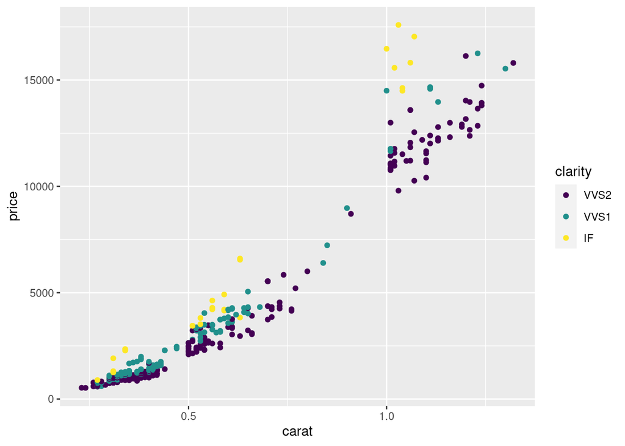

```r
best_diamonds <- diamonds %>%
  filter(
    (clarity %in% c("IF", "VVS1", "VVS2"))
    & (color == "D")
    & (cut == "Ideal")
  )

ggplot(best_diamonds, aes(carat, price, colour = clarity)) +
  geom_point()
```

We can clearly see that when it comes to price IF > VVS1 > VVS2 for a given carat. We can also easily see that there aren’t many diamonds between 0.75 and 1.0 carat. Moreover, above 1.0 carat the price difference between the three clarity levels increases, perhaps because such diamonds are rarer. The power of plots!

How about one more? Let’s opt for a boxplot (AKA box-and-whisker diagram) this time since we have categorical (clarity, colour, cut) and continuous variables (carat, price). It’d be interesting to see to what extent colour affects price:

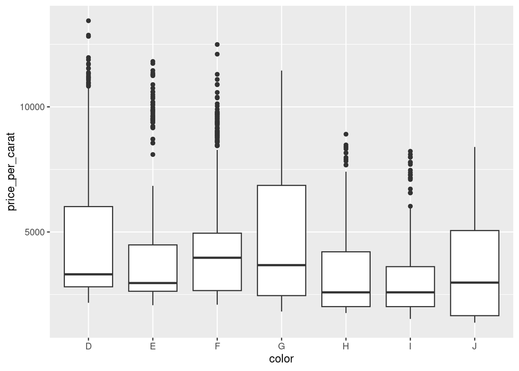

```r
coloured_diamonds <- diamonds %>%
  filter(
    (clarity %in% c("VVS2"))
    & (cut == "Ideal")
  ) %>%
  mutate(price_per_carat = price / carat)

ggplot(coloured_diamonds, aes(color, price_per_carat)) +
  geom_boxplot()
```

It seems like there isn’t a strong trend here, although we can see that the D-F (colourless) diamonds are a bit pricier than the G-J (near-colourless) diamonds.

Now it’s time for *you* to create some plots!

Have some fun trying to visualise the following:

1. How age and weight are distributed amongst the patients.
   1. Can you also make it easy to see the difference between sexes on the same plot?
2. How BMI may be related to response.
   1. Does treatment group impact this relationship?
3. How protein concentration is (or isn’t) correlated with response.
   1. And does treatment group impact this relationship?

**Tip**

Refer to [section 3.5 in R for Data Science](https://r4ds.had.co.nz/data-visualisation.html#facets). You can use the method described there to visualise the difference between the two treatment groups.

## 7 Modelling

**Advanced task**

This will require you to have some knowledge of mathematical modelling, so don’t worry if you find it too tricky, you can skip it. [Chapters 22-25 of R for Data Science](https://r4ds.had.co.nz/model-intro.html) serve as a great introduction.

Try to create a simple model, such as a *decision tree*, capable of predicting whether a given patient will respond or not.

A few considerations:

- You’ll need to split the dataset into *training* and *test* data, the *caret* package can help here with its `createDataPartition()` function.
- Be sure to include only the columns which are relevant for modelling, e.g. subject_id can be safely discarded.
- For decision trees the package *rpart* is a good choice, along with *rpart.plot* to actually view a trained tree!
- A more sophisticated option is a *random forest*. This involves training a collection of decision trees, each on a different subset of the data, and then selecting the best one. Try the package *randomForest*.

Happy Modelling!

## 8 Conclusion

Now that you’ve completed your analysis, you’ll need to interpret your results. What do you think, is Miraculon-A superior to the current standard of care? Is there evidence that the protein that was examined is predictive of a patient being more likely to respond to Miraculon-A?

If you want to wrap things up like a *real* data scientist, then write up your results and conclusion! It doesn’t need to be long, a short slide deck or document is perfectly fine.

**Tip**

You could even use [Quarto](https://quarto.org/), a neat, modern solution to easily create technical documents with integrated code and visuals. It’s the successor to [rmarkdown](https://rmarkdown.rstudio.com/). The document you’re reading right now was created using Quarto!

## 9 Additional resources

- [R for Data Science](https://r4ds.had.co.nz/)
  - This book is a fantastic resource from one of the key people behind Tidyverse - Hadley Wickham. It’s concisely written with clear examples throughout, so you can dip in and out of relevant chapters at your leisure.
- [Tidyverse](https://www.tidyverse.org/packages/)
  - This set of packages is what makes R such a powerful tool for data science. The documentation is first class and there even some handy articles which elaborate on how to get the most out of what’s included.
- [Posit Cloud Primers](https://posit.cloud/learn/primers)
  - A gentle intro to R for those unfamiliar. It variables interactive code blocks which help you learn various functions and methods.
- [Kaggle](https://www.kaggle.com/)
  - Probably the number one place to find new data to play with. Kaggle has a ton of freely available datasets and even competitions you can take part - don’t let being a beginner put you off, many folks are!

## Footnotes

[^1]: Technically, since we’re using Tidyverse, many of the functions we’ll be using will input/output *tibbles*. These are a special kind of dataframe. But since the difference is minor, don’t worry about it for now.